# Week 7 Data Exploration Project

Chequala Fuller

2/20/2021

## OBJECTIVE

For the Week 7 Data Exploration Project, the class has been tasked to answer the research question of “Among colleges that predominantly grant bachelor’s degrees, did it result in more student interest in high-earnings colleges relative to low-earnings ones (as proxied by Google searches for keywords associated with those colleges)?” Given the necessary data, our task includes producing at least one regression and one graph for the analysis, telling the story of what they mean.

## Libraries

Before reading in the necessary data, all libraries required to execute this analysis needed to be loaded.

## Read files

Upon successfully loading the libraries, I read in the appropriate data files. For this data exploration project, we specifically used the provided *Most+Recent+Cohorts+(Scorecard+Elements).csv*, *id_name_link.csv*, and twelve data files with the naming convention pattern *trend_up_to_xx.csv* to perform the analysis. To read these data files, I utilized the *list.files()* and *map()* functions from the *tidyverse* package as well as the *read_csv* from the built-in *readr* package. The following data frames, values, and functions have been assigned and/or created to prepare for the next step which is to tidy up the data.

| Dataframes | No. Observations | No. Variables |
| --- | --- | --- |
| recent_cohorts | 7804 | 122 |
| id_name_link | 3555 | 3 |
| compile_data | 1593740 | 6 |

| Values | Type |
| --- | --- |
| file_list | chr [1:12] |

| Functions | Parameter(s) |
| --- | --- |
| process_file | function(filename) |

## Tidy Data

Though all desired data has been read, it required more clean up to prepare for the regression model(s), graph(s) and analysis. First, I created a new data frame for the id name scorecards and called it scorecd_id_name. I chose to accomplish this by merging the recent_cohorts and id_name_link data frames together by both unit ID (UNITID) and ope ID (OPEID). Next, I created another data frame for the college scorecard through merging the scorecd_id_name data frame with our compile_data data frame by school name (SCHNAME). Considering the objective of the research question, this would give us a more comprehensive spreadsheet to work with.

After establishing the college scorecard (coll_scorecd), some more tidying was still needed and was accomplished by mutating and selecting specific variables for colleges which perdominantly grant bachelor’s degrees (coll_scorecd_bs) to make it easier for modeling. This step also included isolation of the first ten characters of the MONTHORWEEK variable to make it easier to work with the date (DATE) associated with each observation. With the data in decent shape at this point, I was able to identify the threshold for median earnings by calculating the median of all median earnings for all colleges (MEDEARN10). Further defining the threshold for high-earnings (> 41,800 dollars) vs. low-earnings (<41,800 dollars).

As a foundation for the analysis, I have chosen to create a base model with a bivariate OLS regressing MEDEARN10 on SD_INDEX since we are interested in how earning may impact a student’s intterest in a specific college.

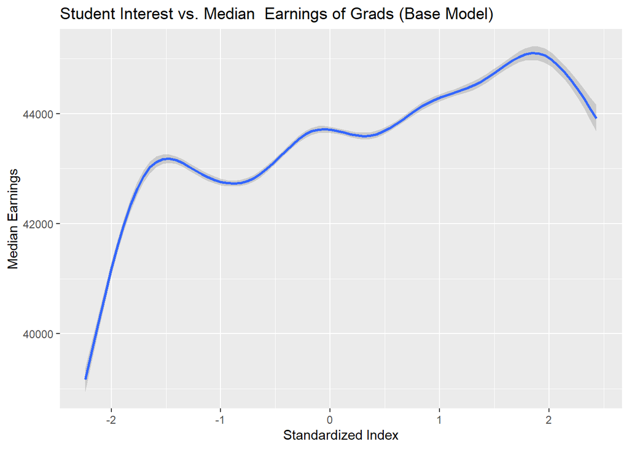

|  | Model 1 | Model 2 |
| --- | --- | --- |
| (Intercept) | 43519.98 *** | 43582.41 *** |
|  | (13.41) | (28.10) |
| SD_INDEX | 775.88 *** | 425.71 *** |
|  | (13.56) | (26.81) |
| N | 754032 | 174911 |
| R2 | 0.00 | 0.00 |
| *** p < 0.001; ** p < 0.01; * p < 0.05. |  |  |

## Model 1 & 2 Graphs

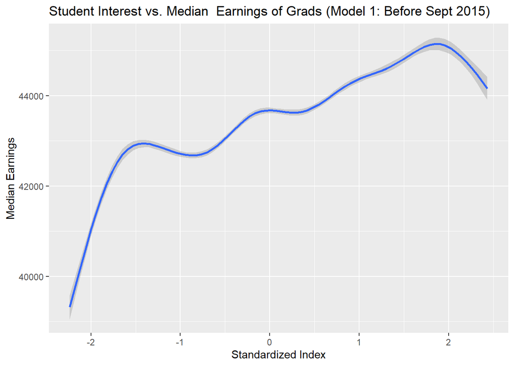

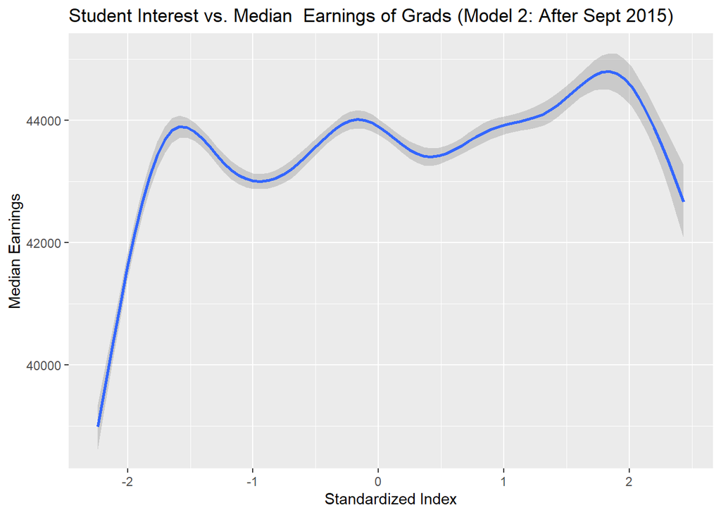

After performing the base models regressing median earnings on standardized index,the graphs had indicated that the models were nonlinear. Between the pre_sept15 regression (model_01) and the post_sept15 (model_02), model_01 looked better. Therefore, I had decided to use model_01 and expand on it by adding multiple controls (i.e. CONTROL, HIGHEARN, and DATE) and a polynomial term to figure out how the variables may effect the MEDEARN10 and if HIGHEARN follows a polynomial. Hopefully, improving the regression model.

## Model 3 & 4 Graphs

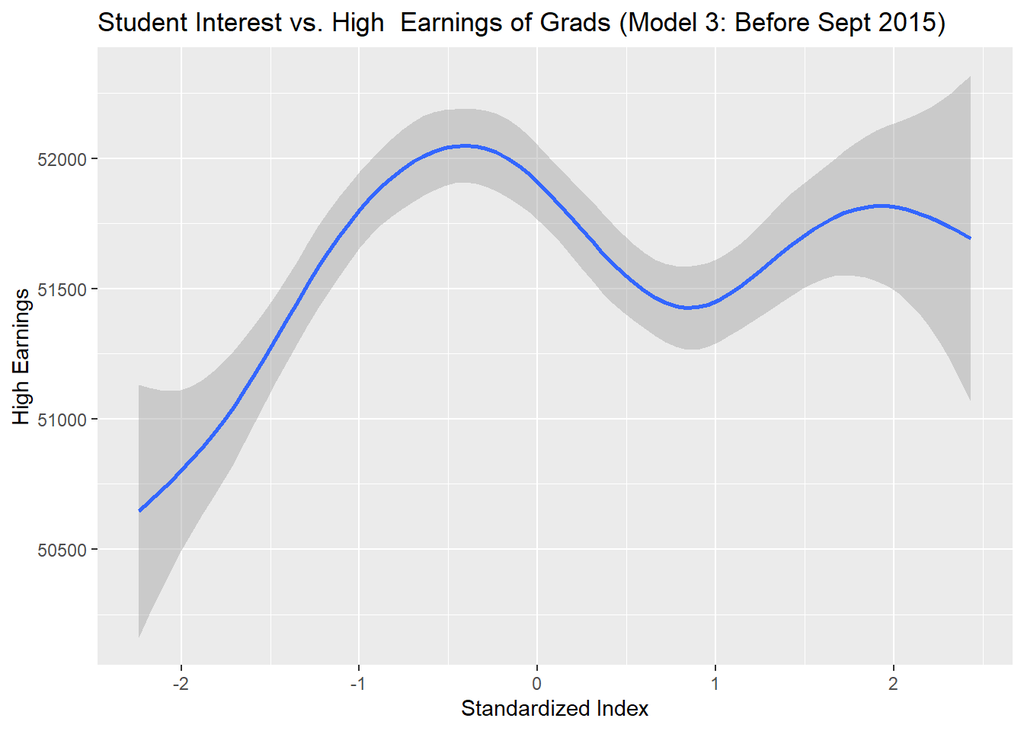

[figure not shown]